# Análisis Estadístico con R

Regresión

VMO

[RUsersEC](http://rusersgroup.com/)

24 de julio de 2018

# Regresión Lineal

## Una idea general

Abordemos las primeras ideas de regresión lineal a través de un ejemplo práctico:

- Abrir la `tabla 2.1`
- Creamos dos variables, Ingreso y Consumo Esperado

```r
ingresos <- seq(80,260,20)
consumoEsperado <- c(65,77,89,101,113,125,137,149,161,173)
```

Ahora:

- Generar un gráfico tipo línea entre ingresos y consumo esperado
- Superponer un gráfico tipo puntos de $X$ e $Y$ (`tabla 2.1`) sobre el gráfico anterior
- Generar un gráfico tipo puntos $X$ e $Y$ en azul
- Superponer un gráfico tipo lineas de Ingresos y consumo esperado sobre el gráfico anterior en azul

```r
familia <- read.csv(file="Tabla2_1.csv",sep=";",dec=".",header=T)
attach(familia)
names(familia)
```

```
## [1] "X" "Y"
```

```r
cbind(ingresos,consumoEsperado)
```

```
##       ingresos consumoEsperado
##  [1,]       80              65
##  [2,]      100              77
##  [3,]      120              89
##  [4,]      140             101
##  [5,]      160             113
##  [6,]      180             125
##  [7,]      200             137
##  [8,]      220             149
##  [9,]      240             161
## [10,]      260             173
```

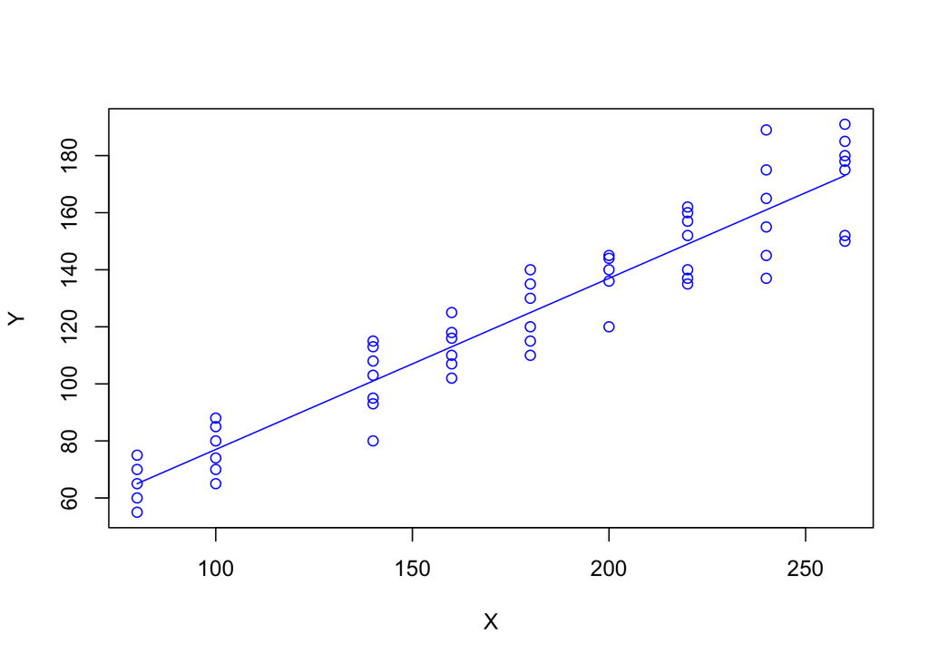

```r
plot(X,Y,col="blue")
lines(ingresos,consumoEsperado,col="blue")
```

- ¿Qué hemos hecho?

$$E(Y|X_i) = f(X_i)$$

$$E(Y|X_i) = \beta_1+\beta_2X_i$$

$$u_i = Y_i - E(Y|X_i)$$

$$Y_i = E(Y|X_i) + u_i$$

- ¿Qué significa que sea lineal?

> El término regresión *lineal* siempre significará una regresión lineal en los parámetros; los $\beta$ (es decir, los parámetros) se elevan sólo a la primera potencia. Puede o no ser lineal en las variables explicativas $X$

Para evidenciar la factibilidad del uso de RL en este caso, vamos a obtener una muestra de la población:

- Creamos una variable indicadora para obtener una muestra `indice=seq(1,55,1)`
- Usamos `sample` para obtener una muestra sin reemplazo del tamaño indicado: `muestra <- sample(indice,size=20)`
- Obtenemos el valor de la variable $X$ en la posición de *muestra* + `ingreso.muestra <- X[muestra]` + `consumo.muestra <- Y[muestra]`

```r
indice <- seq(1,55,1)
muestra <- sample( X ,size=20)
muestra <- sample(indice,size=20)
ingreso.muestra <- X[muestra]
consumo.muestra <- Y[muestra]
```

- Graficamos ingreso.muestra vs consumo.muestra
- Realizar una regresión lineal de las variables muestra:
  - `plot(ingreso.muestra,consumo.muestra)`
  - `ajuste.1=(lm(consumo.muestra\sim ingreso.muestra))`
  - `abline(coef(ajuste.1))`
- Generar una segunda muestra (muestra.2 por ejemplo) y comparar los coeficientes
- ¿Qué conclusiones puede sacar?

```r
plot(ingreso.muestra,consumo.muestra)
ajuste.1 <- (lm(consumo.muestra~ingreso.muestra))
ajuste.1
```

```
##
## Call:
## lm(formula = consumo.muestra ~ ingreso.muestra)
##
## Coefficients:
##     (Intercept)  ingreso.muestra
##         14.4268           0.6158
```

```r
coef(ajuste.1)
```

```
##     (Intercept) ingreso.muestra
##      14.4267516       0.6157871
```

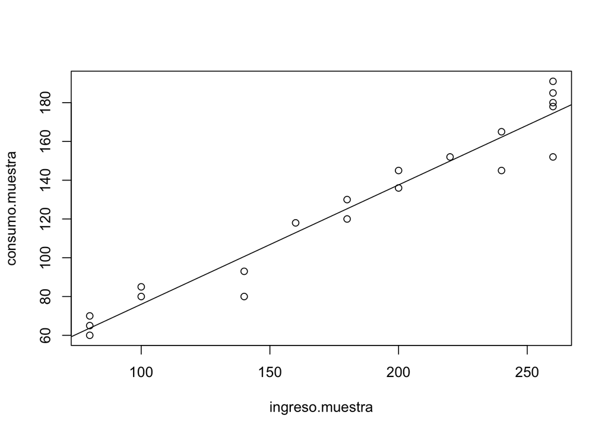

```r
abline(coef(ajuste.1))
```

### Regresión: Paso a paso

La función poblacional sería:

$$Y_i = \beta_1 + \beta_2X_i+u_i$$

Como no es observable, se usa la muestral

$$Y_i=\hat{\beta}_1+\hat{\beta}_2X_i+\hat{u}_i$$

$$Y_i=\hat{Y}_i+\hat{u}_i$$

$$\hat{u}_i = Y_i-\hat{Y}_i$$

$$\hat{u}_i = Y_i- \hat{\beta}_1-\hat{\beta}_2X_i$$

Es por esto que los residuos se obtienen a través de los betas:

$$\label{eq1}
\sum\hat{u}_i^2 =\sum (Y_i- \hat{\beta}_1-\hat{\beta}_2X_i)^2$$

$$\sum\hat{u}_i^2 =f(\hat{\beta}_1,\hat{\beta}_2)$$

$$\hat{\beta}_2 = \frac{S_{xy}}{S_{xx}}$$

$$\hat\beta_1 = \bar{Y} - \hat\beta_2\bar{X}$$
donde
$$S_{xx} = \sum_{i=1}^{n}x_i^2-n\bar{x}^2$$

$$S_{xy} = \sum_{i=1}^{n}x_i y_i-n\bar{x}\bar{y}$$

Abrimos la `tabla3.2`, vamos a obtener:

```r
uu <- "https://raw.githubusercontent.com/vmoprojs/DataLectures/master/Tabla3_2.csv"

consumo <- read.csv(url(uu),sep=";",dec=".",header=TRUE)
attach(consumo)
media_x <- mean(X, na.rm=T)
media_y <- mean(Y, na.rm=T)

n <- length(X)*1

sumcuad_x <- sum(X*X)
sum_xy <- sum(X*Y)

beta_som <- (sum_xy-n*media_x*media_y)/
    (sumcuad_x-n*(media_x^2))
alpha_som  <- media_y-beta_som*media_x
```

- Verificamos lo anterior mediante:

```r
reg.1 <- (lm(Y~X))
coef(reg.1)
```

```
## (Intercept)           X
##  24.4545455   0.5090909
```

- Veamos cómo queda nuestra estimación:

```r
y.ajustado <- alpha_som+beta_som*X
head(cbind(X,y.ajustado))
```

```
##        X y.ajustado
## [1,]  80   65.18182
## [2,] 100   75.36364
## [3,] 120   85.54545
## [4,] 140   95.72727
## [5,] 160  105.90909
## [6,] 180  116.09091
```

- Gráficamente:

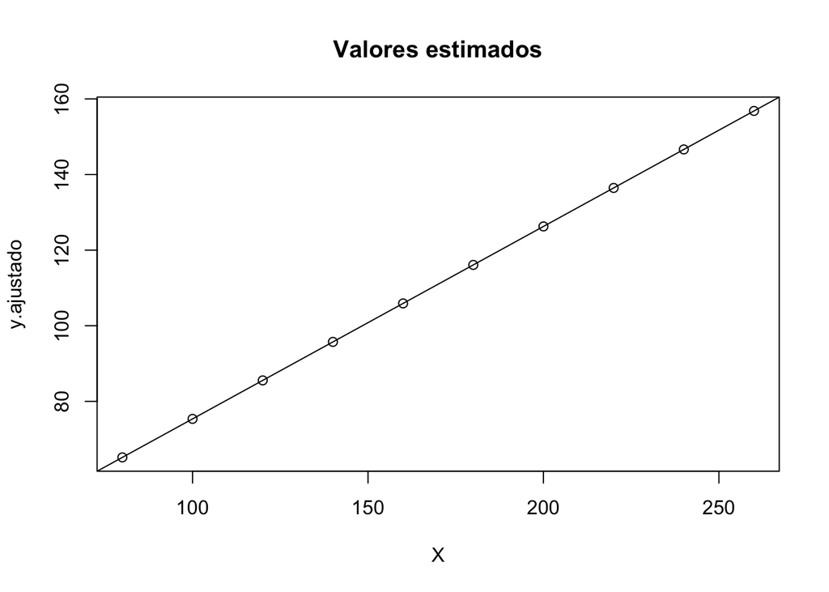

```r
plot(X,y.ajustado,main="Valores estimados")
abline(a=alpha_som,b=beta_som)
```

- Encontremos los residuos:

```r
y.ajustado=alpha_som+beta_som*X
e <- Y-y.ajustado
```

- Comparemos los resultados

```r
head(cbind(X,Y,y.ajustado,e))
```

```
##        X   Y y.ajustado           e
## [1,]  80  70   65.18182   4.8181818
## [2,] 100  65   75.36364 -10.3636364
## [3,] 120  90   85.54545   4.4545455
## [4,] 140  95   95.72727  -0.7272727
## [5,] 160 110  105.90909   4.0909091
## [6,] 180 115  116.09091  -1.0909091
```

- Veamos la media y la correlación

```r
mean(e)
```

```
## [1] -1.421085e-15
```

```r
cor(e,X)
```

```
## [1] 1.150102e-15
```

- Hallemos el coeficiente de determinación o *bondad* de ajuste.
- Para ello necesitamos la suma de cuadrados total y la suma de cuadramos explicada

```r
SCT <- sum((Y-media_y)^2)
SCE <- sum((y.ajustado-media_y)^2)
SCR <- sum(e^2)
R_2 <- SCE/SCT

summary(reg.1)
```

```
##
## Call:
## lm(formula = Y ~ X)
##
## Residuals:
##     Min      1Q  Median      3Q     Max
## -10.364  -4.977   1.409   4.364   8.364
##
## Coefficients:
##             Estimate Std. Error t value Pr(>|t|)
## (Intercept) 24.45455    6.41382   3.813  0.00514 **
## X            0.50909    0.03574  14.243 5.75e-07 ***
## ---
## Signif. codes:  0 '***' 0.001 '**' 0.01 '*' 0.05 '.' 0.1 ' ' 1
##
## Residual standard error: 6.493 on 8 degrees of freedom
## Multiple R-squared:  0.9621, Adjusted R-squared:  0.9573
## F-statistic: 202.9 on 1 and 8 DF,  p-value: 5.753e-07
```

Pruebas de hipótesis:

$$H_0:\beta_2=0$$
$$H_1:\beta_2\neq 0$$

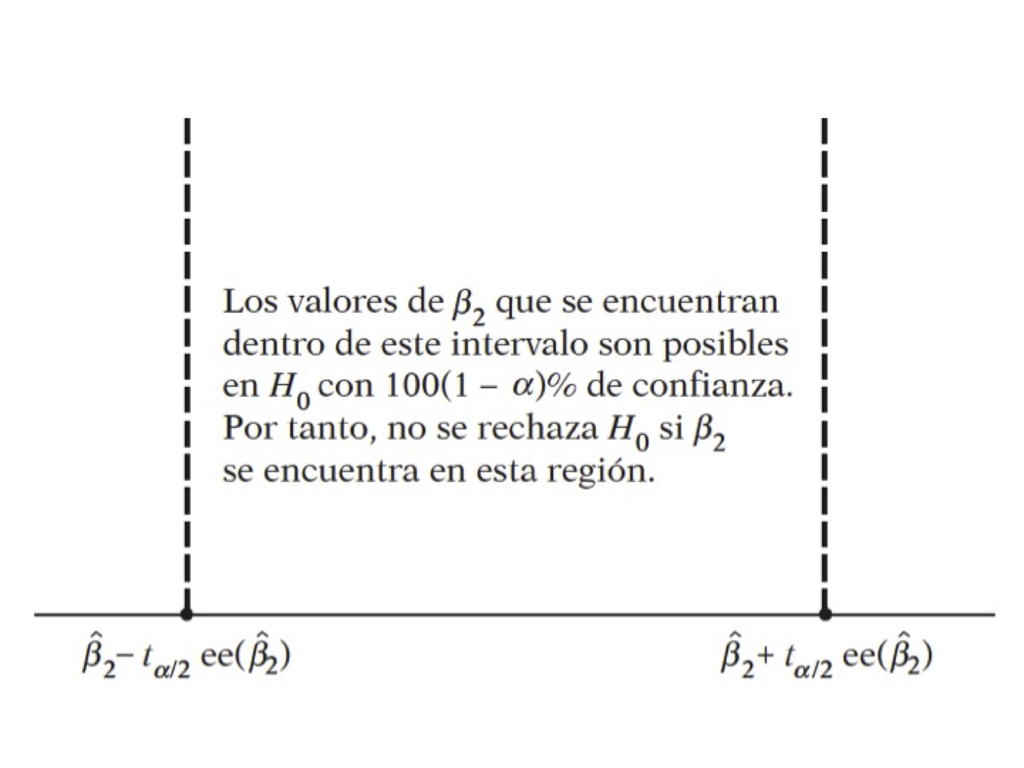

```r
t1 <- (0.43681-0)/0.07832
1-pt(t1,53)
```

```
## [1] 4.222605e-07
```

- ¿Son los coeficientes diferentes de $0.5$?

```r
# H0: beta1 = 0.5
t2 <- (0.43681-0.5)/0.07832
(1-pt(abs(t2),53))
```

```
## [1] 0.2116886
```

Interpretación de los coeficientes

- El coeficiente de la variable dependiente mide la tasa de cambio (derivada=pendiente) del modelo
- La interpretación suele ser *En promedio, el aumento de una unidad en la variable independiente produce un aumento/disminución de $\beta_{i}$ cantidad en la variable dependiente*
- Interprete la regresión anterior.

#### Práctica: Paridad del poder de compra

Abrir la tabla 5.9, las variables son:

```r
uu <- "https://raw.githubusercontent.com/vmoprojs/DataLectures/master/Tabla5_9.csv"
datos <- read.csv(url(uu),sep=";",dec=".",header=TRUE)
attach(datos)
names(datos)
```

```
## [1] "COUNTRY" "BMACLC"  "BMAC."   "EXCH"    "PPP"     "LOCALC"
```

- BMACLC: Big Mac Prices in Local Currency
- BMAC$: Big Mac Prices in $
- EXCH: Actual $ Exchange Rate 4/17/2001
- PPP: Implied Purchasing-Power Parity of the Dollar: Local Price Divided by Price in United States
- LOCALC: Local Currency Under (-)/Over (+) Valuation Against $, Percent

Empezamos con el buen `summary`. ¿Notan algo raro?

- Debemos limpiar los datos

```r
datos$EXCH[which(  EXCH  == -99999)] <- NA
datos$PPP[which(  PPP == -99999)] <- NA
datos$LOCALC[which(  LOCALC   ==-99999)] <- NA
```

Regresamos la paridad del poder de compra en la tasa de cambio

```r
reg1 <- lm(EXCH~PPP)
summary(reg1)
```

```
##
## Call:
## lm(formula = EXCH ~ PPP)
##
## Residuals:
##    Min     1Q Median     3Q    Max
## -212.9 -211.0 -208.0 -186.3 4827.8
##
## Coefficients:
##              Estimate Std. Error t value Pr(>|t|)
## (Intercept) 2.116e+02  1.675e+02   1.264    0.216
## PPP         1.005e+00  9.306e-03 107.990   <2e-16 ***
## ---
## Signif. codes:  0 '***' 0.001 '**' 0.01 '*' 0.05 '.' 0.1 ' ' 1
##
## Residual standard error: 920.1 on 29 degrees of freedom
## Multiple R-squared:  0.9975, Adjusted R-squared:  0.9974
## F-statistic: 1.166e+04 on 1 and 29 DF,  p-value: < 2.2e-16
```

```r
reg2 <- lm(EXCH[-13]~PPP[-13])
summary(reg2)
```

```
##
## Call:
## lm(formula = EXCH[-13] ~ PPP[-13])
##
## Residuals:
##    Min     1Q Median     3Q    Max
## -203.1 -201.2 -199.0 -179.6 4838.5
##
## Coefficients:
##              Estimate Std. Error t value Pr(>|t|)
## (Intercept) 2.018e+02  1.731e+02   1.166    0.254
## PPP[-13]    1.005e+00  9.465e-03 106.157   <2e-16 ***
## ---
## Signif. codes:  0 '***' 0.001 '**' 0.01 '*' 0.05 '.' 0.1 ' ' 1
##
## Residual standard error: 934.8 on 28 degrees of freedom
## Multiple R-squared:  0.9975, Adjusted R-squared:  0.9974
## F-statistic: 1.127e+04 on 1 and 28 DF,  p-value: < 2.2e-16
```

```r
reg3 <- lm(log(EXCH)~log(PPP))
summary(reg3)
```

```
##
## Call:
## lm(formula = log(EXCH) ~ log(PPP))
##
## Residuals:
##      Min       1Q   Median       3Q      Max
## -0.70587 -0.24564 -0.05721  0.26862  0.42295
##
## Coefficients:
##             Estimate Std. Error t value Pr(>|t|)
## (Intercept)  0.34363    0.08613    3.99 0.000432 ***
## log(PPP)     1.00231    0.02463   40.69  < 2e-16 ***
## ---
## Signif. codes:  0 '***' 0.001 '**' 0.01 '*' 0.05 '.' 0.1 ' ' 1
##
## Residual standard error: 0.3206 on 28 degrees of freedom
##   (1 observation deleted due to missingness)
## Multiple R-squared:  0.9834, Adjusted R-squared:  0.9828
## F-statistic:  1655 on 1 and 28 DF,  p-value: < 2.2e-16
```

La PPA sostiene que con una unidad de moneda debe ser posible comprar la misma canasta de bienes en todos los países.

#### Práctica: Sueño

De la carpeta *Datos*, abrir `sleep.xls`

```r
uu <- "https://raw.githubusercontent.com/vmoprojs/DataLectures/master/sleep75.csv"
datos <- read.csv(url(uu), header = FALSE)
```

agregamos los nombres:

```r
names (datos) <- c("age","black","case","clerical","construc","educ","earns74","gdhlth","inlf", "leis1", "leis2", "leis3", "smsa", "lhrwage", "lothinc", "male", "marr", "prot", "rlxall", "selfe", "sleep", "slpnaps", "south", "spsepay", "spwrk75", "totwrk" , "union" , "worknrm" , "workscnd", "exper" , "yngkid","yrsmarr", "hrwage", "agesq")
```

Veamos los datos gráficamente y corramos la regresión:

```r
attach(datos)
```

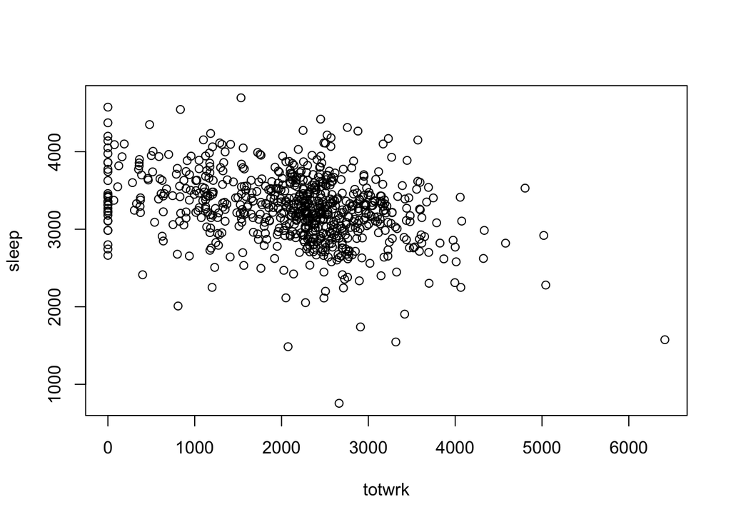

```r
#totwrk minutos trabajados por semana
#sleep minutos dormidos por semana
plot(totwrk,sleep)
```

```r
dormir <- lm(sleep~totwrk)
summary(dormir)
```

```
##
## Call:
## lm(formula = sleep ~ totwrk)
##
## Residuals:
##      Min       1Q   Median       3Q      Max
## -2429.94  -240.25     4.91   250.53  1339.72
##
## Coefficients:
##               Estimate Std. Error t value Pr(>|t|)
## (Intercept) 3586.37695   38.91243  92.165   <2e-16 ***
## totwrk        -0.15075    0.01674  -9.005   <2e-16 ***
## ---
## Signif. codes:  0 '***' 0.001 '**' 0.01 '*' 0.05 '.' 0.1 ' ' 1
##
## Residual standard error: 421.1 on 704 degrees of freedom
## Multiple R-squared:  0.1033, Adjusted R-squared:  0.102
## F-statistic: 81.09 on 1 and 704 DF,  p-value: < 2.2e-16
```

- ¿Existe una relación entre estas variables?
- Interprete el modelo

Intervalo de confianza para $\beta_2$ y veamos los residuos

```r
-0.15084-2*c(-0.01677,0.01677)
```

```
## [1] -0.11730 -0.18438
```

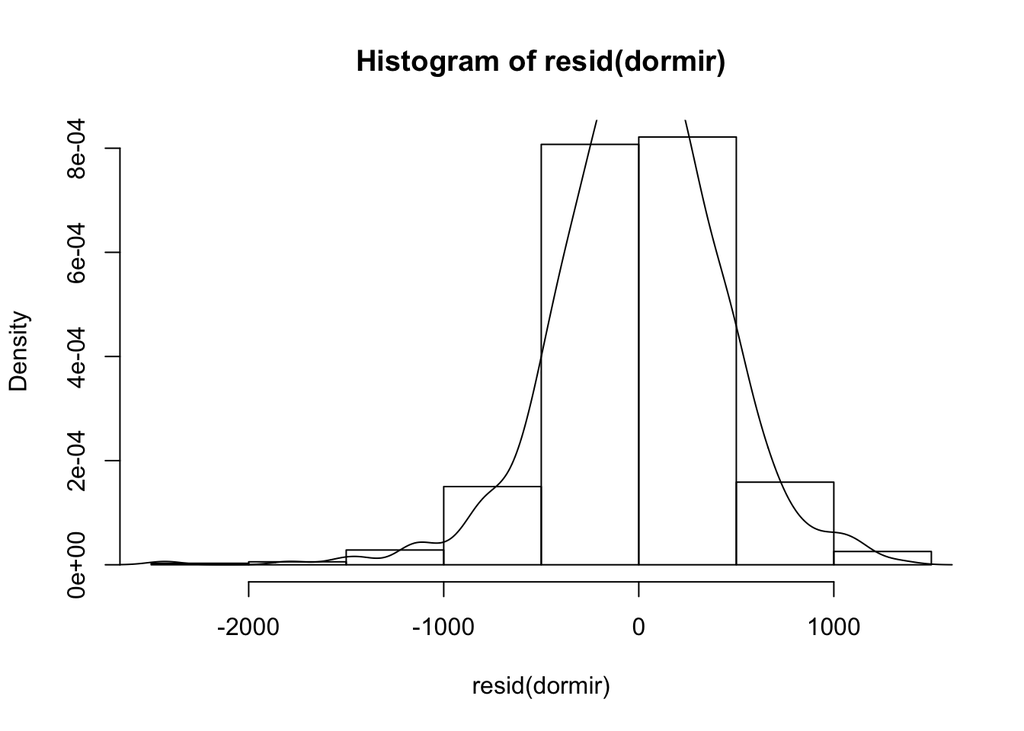

```r
hist(resid(dormir),freq=F)
lines(density(resid(dormir)))
```

Derivaciones del modelo

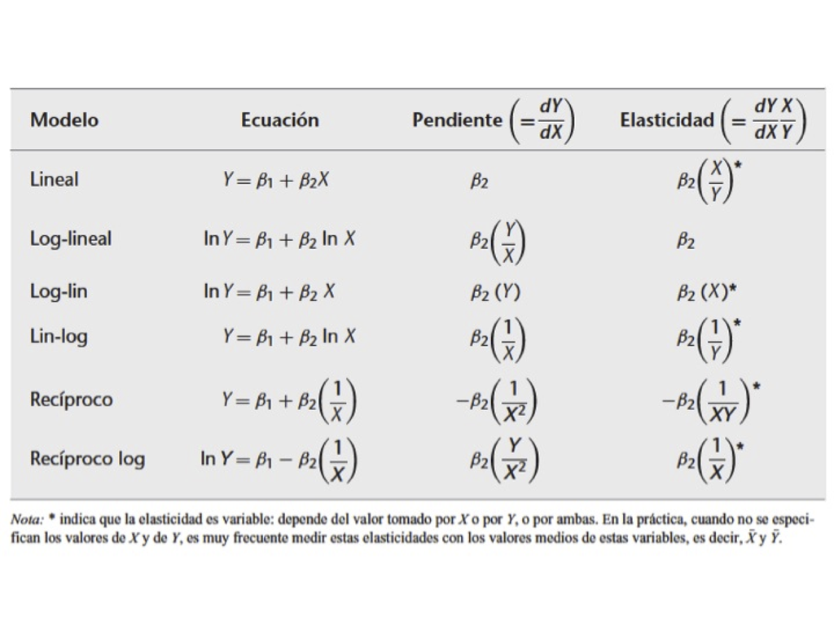

## Transformaciones Lineales

Abrir la `tabla 31.3`, regresar el ingreso per cápita en el número de celulares por cada 100 personas:

```r
uu <- "https://raw.githubusercontent.com/vmoprojs/DataLectures/master/Table%2031_3.csv"
datos <- read.csv(url(uu),sep=";",dec=".",header=TRUE)
attach(datos)
```

```r
reg.1 <- lm(Cellphone ~ Pcapincome)
summary(reg.1)
```

```
##
## Call:
## lm(formula = Cellphone ~ Pcapincome)
##
## Residuals:
##     Min      1Q  Median      3Q     Max
## -45.226 -10.829  -2.674   8.950  47.893
##
## Coefficients:
##              Estimate Std. Error t value Pr(>|t|)
## (Intercept) 1.248e+01  6.109e+00   2.043   0.0494 *
## Pcapincome  2.313e-03  3.158e-04   7.326  2.5e-08 ***
## ---
## Signif. codes:  0 '***' 0.001 '**' 0.01 '*' 0.05 '.' 0.1 ' ' 1
##
## Residual standard error: 19.92 on 32 degrees of freedom
## Multiple R-squared:  0.6265, Adjusted R-squared:  0.6148
## F-statistic: 53.67 on 1 and 32 DF,  p-value: 2.498e-08
```

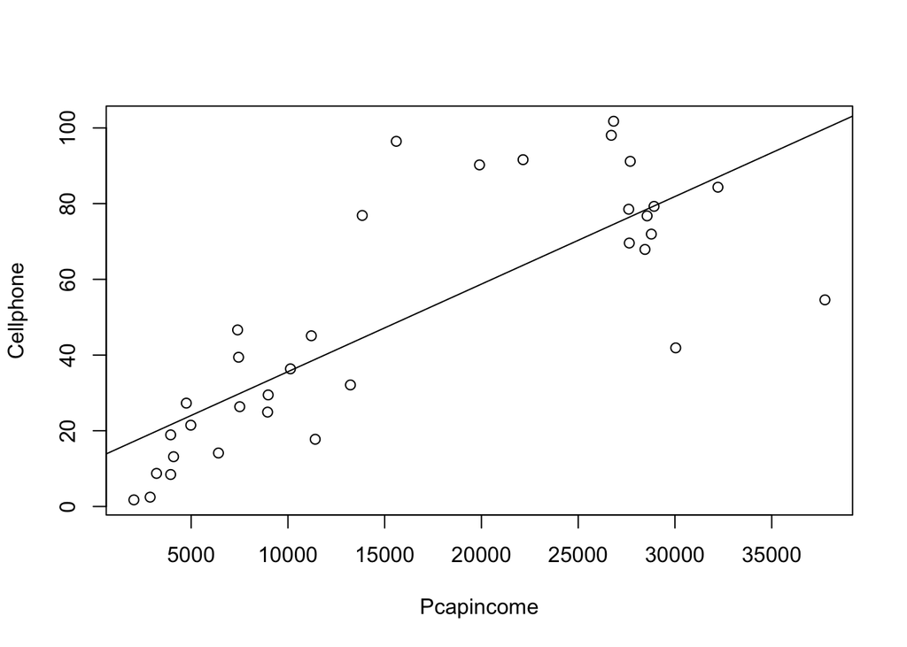

```r
plot(Pcapincome,Cellphone)
abline(coef(reg.1))
```

### Modelo recíproco

Abrir la `tabla 6.4`, regresar el Producto Nacional Bruto (PGNP) en la tasa de mortalidad (CM).

```r
uu <- "https://raw.githubusercontent.com/vmoprojs/DataLectures/master/tabla_6_4.csv"
datos <- read.csv(url(uu),sep=";",dec=".",header=TRUE)
attach(datos)
names(datos)
```

```
## [1] "CM"   "FLR"  "PGNP" "TFR"
```

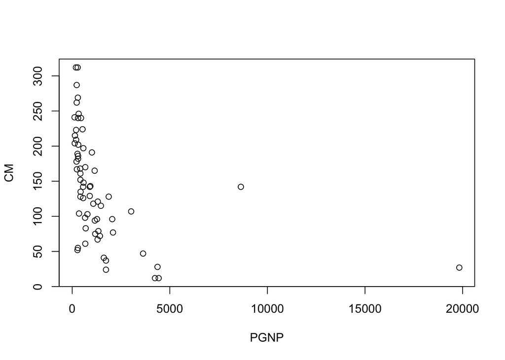

```r
plot(CM~ PGNP)
```

```r
reg1 <- lm(CM ~ PGNP)
summary(reg1)
```

```
##
## Call:
## lm(formula = CM ~ PGNP)
##
## Residuals:
##      Min       1Q   Median       3Q      Max
## -113.764  -53.111   -6.685   48.064  157.758
##
## Coefficients:
##               Estimate Std. Error t value Pr(>|t|)
## (Intercept) 157.424441   9.845583  15.989  < 2e-16 ***
## PGNP         -0.011364   0.003233  -3.516 0.000826 ***
## ---
## Signif. codes:  0 '***' 0.001 '**' 0.01 '*' 0.05 '.' 0.1 ' ' 1
##
## Residual standard error: 69.93 on 62 degrees of freedom
## Multiple R-squared:  0.1662, Adjusted R-squared:  0.1528
## F-statistic: 12.36 on 1 and 62 DF,  p-value: 0.0008262
```

```r
reg2 <- lm(CM~I(1/PGNP))
summary(reg2)
```

```
##
## Call:
## lm(formula = CM ~ I(1/PGNP))
##
## Residuals:
##      Min       1Q   Median       3Q      Max
## -130.806  -36.410    2.871   31.686  132.801
##
## Coefficients:
##             Estimate Std. Error t value Pr(>|t|)
## (Intercept)    81.79      10.83   7.551 2.38e-10 ***
## I(1/PGNP)   27273.17    3760.00   7.254 7.82e-10 ***
## ---
## Signif. codes:  0 '***' 0.001 '**' 0.01 '*' 0.05 '.' 0.1 ' ' 1
##
## Residual standard error: 56.33 on 62 degrees of freedom
## Multiple R-squared:  0.4591, Adjusted R-squared:  0.4503
## F-statistic: 52.61 on 1 and 62 DF,  p-value: 7.821e-10
```

### Modelo log-lineal

Abrir los datos `ceosal2.xls`,

```r
uu <- "https://raw.githubusercontent.com/vmoprojs/DataLectures/master/ceosal2.csv"
datos <- read.csv(url(uu), header = FALSE)
names(datos) = c("salary", "age", "college", "grad", "comten", "ceoten", "sales", "profits","mktval", "lsalary", "lsales", "lmktval", "comtensq", "ceotensq", "profmarg")
attach(datos)
```

Regresar la antigüedad del CEO en el logaritmo del salario.

```r
summary(lm(lsalary~ceoten))
```

```
##
## Call:
## lm(formula = lsalary ~ ceoten)
##
## Residuals:
##      Min       1Q   Median       3Q      Max
## -2.15314 -0.38319 -0.02251  0.44439  1.94337
##
## Coefficients:
##             Estimate Std. Error t value Pr(>|t|)
## (Intercept) 6.505498   0.067991  95.682   <2e-16 ***
## ceoten      0.009724   0.006364   1.528    0.128
## ---
## Signif. codes:  0 '***' 0.001 '**' 0.01 '*' 0.05 '.' 0.1 ' ' 1
##
## Residual standard error: 0.6038 on 175 degrees of freedom
## Multiple R-squared:  0.01316,    Adjusted R-squared:  0.007523
## F-statistic: 2.334 on 1 and 175 DF,  p-value: 0.1284
```

- Hay una probabilidad de equivocarnos del 12.84% si rechazamos la hipótesis nula
- No hay evidencia de la entiguedad tenga relación con el salario
- Los CEO con 0 a?os de antiguedad entran ganando `exp(6.505)=668.4757` miles de USD `exp(6.505)`

### Regresión a través del origen

Abrir la `tabla 6.1`, regresar X (rendimientos excedentes de un índice acciones del sector de bienes de consumo cíclico) en Y (rendimientos excedentes de un índice acciones de todo el mercado de valores en el Reino Unido)

```r
uu <- "https://raw.githubusercontent.com/vmoprojs/DataLectures/master/Table%206_1.csv"
datos <- read.csv(url(uu),sep=";",dec=".",header=TRUE)
attach(datos)
```

```r
lmod1 <- lm(Y~ -1 + X)
summary(lmod1)
```

```
##
## Call:
## lm(formula = Y ~ -1 + X)
##
## Residuals:
##      Min       1Q   Median       3Q      Max
## -20.8053  -3.9760  -0.2102   3.0745  14.7680
##
## Coefficients:
##   Estimate Std. Error t value Pr(>|t|)
## X   1.1555     0.0744   15.53   <2e-16 ***
## ---
## Signif. codes:  0 '***' 0.001 '**' 0.01 '*' 0.05 '.' 0.1 ' ' 1
##
## Residual standard error: 5.549 on 239 degrees of freedom
## Multiple R-squared:  0.5023, Adjusted R-squared:  0.5003
## F-statistic: 241.2 on 1 and 239 DF,  p-value: < 2.2e-16
```

```r
lmod2 <- lm(Y~  X)
summary(lmod2)
```

```
##
## Call:
## lm(formula = Y ~ X)
##
## Residuals:
##      Min       1Q   Median       3Q      Max
## -20.4122  -3.5274   0.2316   3.4774  15.1150
##
## Coefficients:
##             Estimate Std. Error t value Pr(>|t|)
## (Intercept) -0.44748    0.36294  -1.233    0.219
## X            1.17113    0.07539  15.535   <2e-16 ***
## ---
## Signif. codes:  0 '***' 0.001 '**' 0.01 '*' 0.05 '.' 0.1 ' ' 1
##
## Residual standard error: 5.543 on 238 degrees of freedom
## Multiple R-squared:  0.5035, Adjusted R-squared:  0.5014
## F-statistic: 241.3 on 1 and 238 DF,  p-value: < 2.2e-16
```

- El coeficiente de la pendiente no es sólo estadísticamente significativo, sino que es significativamente mayor que 1 (¿puede verificar esto?).
- Si un coeficiente Beta es mayor que 1, se dice que ese título (en este caso, un portafolios de 104 acciones) es volátil

## Regresión Lineal Múltiple

Abrir los datos `hprice1.xls`. Correr los siguientes modelos e interpretarlos:

```r
uu <- "https://raw.githubusercontent.com/vmoprojs/DataLectures/master/hprice1.csv"
precios <- read.csv(url(uu), header = FALSE)

names(precios)=c("price"   ,  "assess"  ,
                 "bdrms"  ,   "lotsize"  ,
                 "sqrft"   ,  "colonial",
                 "lprice"  ,  "lassess" ,
                 "llotsize" , "lsqrft")

attach(precios)
```

```r
modelo1 <- lm(lprice ~ lassess + llotsize + lsqrft + bdrms)
summary(modelo1)
```

```
##
## Call:
## lm(formula = lprice ~ lassess + llotsize + lsqrft + bdrms)
##
## Residuals:
##      Min       1Q   Median       3Q      Max
## -0.53337 -0.06333  0.00686  0.07836  0.60825
##
## Coefficients:
##              Estimate Std. Error t value Pr(>|t|)
## (Intercept)  0.263745   0.569665   0.463    0.645
## lassess      1.043065   0.151446   6.887 1.01e-09 ***
## llotsize     0.007438   0.038561   0.193    0.848
## lsqrft      -0.103239   0.138431  -0.746    0.458
## bdrms        0.033839   0.022098   1.531    0.129
## ---
## Signif. codes:  0 '***' 0.001 '**' 0.01 '*' 0.05 '.' 0.1 ' ' 1
##
## Residual standard error: 0.1481 on 83 degrees of freedom
## Multiple R-squared:  0.7728, Adjusted R-squared:  0.7619
## F-statistic: 70.58 on 4 and 83 DF,  p-value: < 2.2e-16
```

```r
modelo2 <- lm(lprice ~ llotsize + lsqrft + bdrms)
summary(modelo2)
```

```
##
## Call:
## lm(formula = lprice ~ llotsize + lsqrft + bdrms)
##
## Residuals:
##      Min       1Q   Median       3Q      Max
## -0.68422 -0.09178 -0.01584  0.11213  0.66899
##
## Coefficients:
##             Estimate Std. Error t value Pr(>|t|)
## (Intercept) -1.29704    0.65128  -1.992   0.0497 *
## llotsize     0.16797    0.03828   4.388 3.31e-05 ***
## lsqrft       0.70023    0.09287   7.540 5.01e-11 ***
## bdrms        0.03696    0.02753   1.342   0.1831
## ---
## Signif. codes:  0 '***' 0.001 '**' 0.01 '*' 0.05 '.' 0.1 ' ' 1
##
## Residual standard error: 0.1846 on 84 degrees of freedom
## Multiple R-squared:  0.643,  Adjusted R-squared:  0.6302
## F-statistic: 50.42 on 3 and 84 DF,  p-value: < 2.2e-16
```

```r
modelo3 <- lm(lprice ~  bdrms)
summary(modelo3)
```

```
##
## Call:
## lm(formula = lprice ~ bdrms)
##
## Residuals:
##      Min       1Q   Median       3Q      Max
## -0.99586 -0.17202 -0.00319  0.14974  0.71355
##
## Coefficients:
##             Estimate Std. Error t value Pr(>|t|)
## (Intercept)  5.03649    0.12635  39.862  < 2e-16 ***
## bdrms        0.16723    0.03447   4.851 5.43e-06 ***
## ---
## Signif. codes:  0 '***' 0.001 '**' 0.01 '*' 0.05 '.' 0.1 ' ' 1
##
## Residual standard error: 0.2706 on 86 degrees of freedom
## Multiple R-squared:  0.2148, Adjusted R-squared:  0.2057
## F-statistic: 23.53 on 1 and 86 DF,  p-value: 5.426e-06
```

#### Predicción

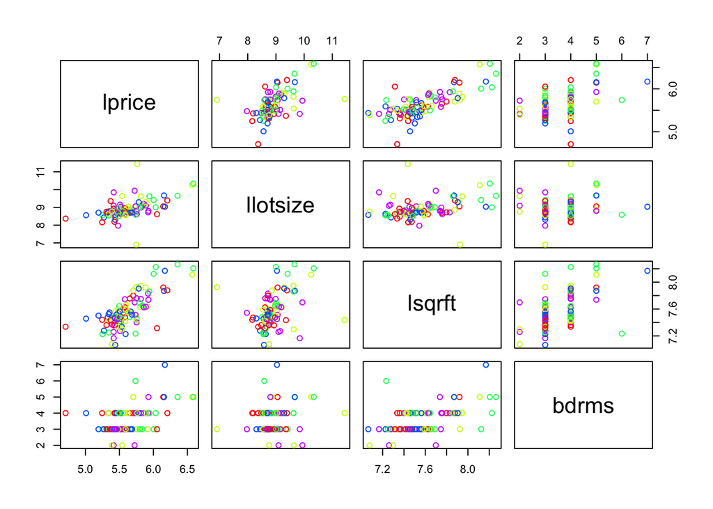

```r
pairs(cbind(lprice,llotsize , lsqrft , bdrms), col=rainbow(5))
```

- Forma 1 de predicción:

```r
tamano_casa <- 8000
cuartos <- 4
tamano_lote <- 2100

coef(modelo2)
```

```
## (Intercept)    llotsize      lsqrft       bdrms
## -1.29704057  0.16796682  0.70023213  0.03695833
```

```r
valores <- c(1,log(tamano_lote),log(tamano_casa),cuartos)
valores
```

```
## [1] 1.000000 7.649693 8.987197 4.000000
```

```r
sum(valores*coef(modelo2))
```

```
## [1] 6.428811
```

```r
exp(sum(valores*coef(modelo2)))
```

```
## [1] 619.4372
```

- Forma 2 de predicción:

```r
datos.nuevos <- data.frame(llotsize=log(2100),lsqrft=log(8000),bdrms=4)
predict.lm(modelo2,newdata=datos.nuevos,se.fit=T)
```

```
## $fit
##        1
## 6.428811
##
## $se.fit
## [1] 0.1479752
##
## $df
## [1] 84
##
## $residual.scale
## [1] 0.1846026
```

### RLM: Cobb-Douglas

El modelo:

$$Y_i = \beta_1X_{2i}^{\beta_2}X_{3i}^{\beta_3}e^{u_i}$$

donde

- $Y$: producción
- $X_2$: insumo trabajo
- $X_3$: insumo capital
- $u$: término de perturbación
- $e$: base del logaritmo

Notemos que el modelo es multiplicativo, si tomamos la derivada obetenemos un modelo más famliar respecto a la regresión lineal múltiple:

$$lnY_i = ln\beta_1 + \beta_2ln(X_{2i})+ \beta_3ln(X_{3i}) + u_i$$

La interpretación de los coeficientes es (Gujarati and Porter 2010):

1. $\beta_2$ es la elasticidad (parcial) de la producción respecto del insumo trabajo, es decir, mide el cambio porcentual en la producción debido a una variación de 1% en el insumo trabajo, con el insumo capital constante.
2. De igual forma, $\beta_3$ es la elasticidad (parcial) de la producción respecto del insumo capital, con el insumo trabajo constante.
3. La suma ($\beta_2+\beta_3$) da información sobre los rendimientos a escala, es decir, la respuesta de la producción a un cambio proporcional en los insumos. Si esta suma es 1, existen rendimientos constantes a escala, es decir, la duplicación de los insumos duplica la producción, la triplicación de los insumos la triplica, y así sucesivamente. Si la suma es menor que 1, existen rendimientos decrecientes a escala: al duplicar los insumos, la producción crece en menos del doble. Por último, si la suma es mayor que 1, hay rendimientos crecientes a escala; la duplicación de los insumos aumenta la producción en más del doble.

Abrir la `tabla 7.3`. Regresar las horas de trabajo ($X_2$) e Inversión de Capital ($X_3$) en el Valor Agregado ($Y$)

```r
uu <- "https://raw.githubusercontent.com/vmoprojs/DataLectures/master/tabla7_3.csv"
# datos <- read.csv(file="tabla7_3.csv",sep=";",dec=".",header=TRUE)
datos <- read.csv(url(uu),sep=";",dec=".",header=TRUE)
attach(datos)
```

```r
W <- log(X2)

K <- log(X3)

LY <- log(Y)

reg.1 <- lm(LY~W+K)
summary(reg.1)
```

```
##
## Call:
## lm(formula = LY ~ W + K)
##
## Residuals:
##      Min       1Q   Median       3Q      Max
## -0.15919 -0.02917  0.01179  0.04087  0.09640
##
## Coefficients:
##             Estimate Std. Error t value Pr(>|t|)
## (Intercept)  -3.3387     2.4491  -1.363 0.197845
## W             1.4987     0.5397   2.777 0.016750 *
## K             0.4899     0.1020   4.801 0.000432 ***
## ---
## Signif. codes:  0 '***' 0.001 '**' 0.01 '*' 0.05 '.' 0.1 ' ' 1
##
## Residual standard error: 0.0748 on 12 degrees of freedom
## Multiple R-squared:  0.8891, Adjusted R-squared:  0.8706
## F-statistic: 48.08 on 2 and 12 DF,  p-value: 1.864e-06
```

```r
aov(reg.1)
```

```
## Call:
##    aov(formula = reg.1)
##
## Terms:
##                         W         K Residuals
## Sum of Squares  0.4090674 0.1289876 0.0671410
## Deg. of Freedom         1         1        12
##
## Residual standard error: 0.07480028
## Estimated effects may be unbalanced
```

- Las elasticidades de la producción respecto del trabajo y el capital fueron 1.49 y 0.48.

Ahora, si existen rendimientos constantes a escala (un cambio equi proporcional en la producción ante un cambio equiproporcional en los insumos), la teoría económica sugeriría que:

$$\beta_2 +\beta_3 = 1$$

```r
LY_K <- log(Y/X3)
W_K <- log(X2/X3)


reg.2 <- lm(LY_K~W_K)
summary(reg.2)
```

```
##
## Call:
## lm(formula = LY_K ~ W_K)
##
## Residuals:
##       Min        1Q    Median        3Q       Max
## -0.164785 -0.041608 -0.008268  0.076112  0.098587
##
## Coefficients:
##             Estimate Std. Error t value Pr(>|t|)
## (Intercept)   1.7083     0.4159   4.108  0.00124 **
## W_K           0.3870     0.0933   4.147  0.00115 **
## ---
## Signif. codes:  0 '***' 0.001 '**' 0.01 '*' 0.05 '.' 0.1 ' ' 1
##
## Residual standard error: 0.08388 on 13 degrees of freedom
## Multiple R-squared:  0.5695, Adjusted R-squared:  0.5364
## F-statistic:  17.2 on 1 and 13 DF,  p-value: 0.001147
```

```r
aov(reg.2)
```

```
## Call:
##    aov(formula = reg.2)
##
## Terms:
##                        W_K  Residuals
## Sum of Squares  0.12100534 0.09145854
## Deg. of Freedom          1         13
##
## Residual standard error: 0.08387653
## Estimated effects may be unbalanced
```

**¿Se cumple la hipótesis nula? ¿Existen rendimientos constantes de escala?**

Una forma de responder a la pregunta es mediante la prueba $t$, para $Ho: \beta_2 +\beta_3 = 1$, tenemos

$$t = \frac{(\hat{\beta}_2+\hat{\beta}_3)-(\beta_2+\beta_3)}{ee(\hat{\beta}_2+\hat{\beta}_3)}$$
$$t = \frac{(\hat{\beta}_2+\hat{\beta}_3)-1}{\sqrt{var(\hat{\beta}_2)+var(\hat{\beta}_3)+2cov(\hat{\beta}_2,\hat{\beta}_3})}$$
donde la información nececesaria para obtener $cov(\hat{\beta}_2,\hat{\beta}_3)$ en `R` es `vcov(fit.model)` y `fit.model` es el ajuste del modelo.

Otra forma de hacer la prueba es mediante el estadístico $F$:

$$F = \frac{Q_2/gl}{Q_4/gl}$$
$$F = \frac{(SCE_{R}-SCE_{NR})/m}{SCR_{NR}/(n-k)}$$

donde $m$ es el número de restricciones lineales y $k$ es el número de parámetros de la regresión no restringida.

```r
SCRNR <- 0.0671410
SCRRes <- 0.09145854
numero_rest <- 1
grad <- 12

est_F <- ((SCRRes-SCRNR)/numero_rest)/(SCRNR/grad)
est_F
```

```
## [1] 4.346234
```

```r
valor.p <- 1-pf(est_F,1,12)
valor.p
```

```
## [1] 0.05912184
```

No se tiene suficiente evidencia para rechazar la hipótesis nula de que sea una economía de escala.

Notemos que existe una relación directa entre el coeficiente de determinación o bondad de ajuste $R^2$ y $F$. En primero lugar, recordemos la descomposición de los errores:

$$SCT = SCE + SCR$$

$$\sum_{i=1}^{n}(Y-\bar{Y})^2 = \sum_{i=1}^{n}(\hat{Y}-\bar{Y})^2 + \sum_{i=1}^{n}(\hat{u})^2$$

De cuyos elementos podemos obtener tanto $R^2$ como $F$:

$$R^2 = \frac{SCE}{SCT}$$

$$R^2 = \frac{SCE/(k-1)}{SCT/(n-k)}$$

donde $k$ es el número de variables (incluido el intercepto) y sigue una distribución $F$ con $k-1$ y $n-k$ grados de libertad.

### RLM: Dicotómicas

Abrir la `tabla 9.1`. ¿Hay alguna diferencia entre la ubicación del estado en los salarios?

```r
uu <- "https://raw.githubusercontent.com/vmoprojs/DataLectures/master/Table%209_1.csv"
datos <- read.csv(url(uu),sep=";",dec=".",header=TRUE)
attach(datos)
names(datos)
```

```
## [1] "State"    "Salary"   "Spending" "D2"       "D3"
```

- “State”
- “Salary” salario prmedio de los profesores
- “Spending” gasto promedio en cada estudiante
- “D2” 1 si el estado se encuentra en el norte este/centr de EEUU
- “D3” 1 si el estado se encuentra en el Sur de EEUU
- D1 podria ser lo que no es ni D2 ni D3 (0,0)

```r
reg1 <- lm(Salary~D2+D3)
summary(reg1)
```

```
##
## Call:
## lm(formula = Salary ~ D2 + D3)
##
## Residuals:
##    Min     1Q Median     3Q    Max
## -14161  -4566  -1638   4632  15625
##
## Coefficients:
##             Estimate Std. Error t value Pr(>|t|)
## (Intercept)    48015       1857  25.853   <2e-16 ***
## D2              1524       2363   0.645    0.522
## D3             -1721       2467  -0.698    0.489
## ---
## Signif. codes:  0 '***' 0.001 '**' 0.01 '*' 0.05 '.' 0.1 ' ' 1
##
## Residual standard error: 6696 on 48 degrees of freedom
## Multiple R-squared:  0.04397,    Adjusted R-squared:  0.004134
## F-statistic: 1.104 on 2 and 48 DF,  p-value: 0.3399
```

Esto es un análisis de varianza, se analiza la var continua (salarios) con factores (categorias)

¿Hay alguna diferencia entre la ubicación del estado en los salarios?

```r
reg2 <- lm(Salary~Spending+D2+D3)
summary(reg2)
```

```
##
## Call:
## lm(formula = Salary ~ Spending + D2 + D3)
##
## Residuals:
##    Min     1Q Median     3Q    Max
## -10556  -2471    106   2066  15084
##
## Coefficients:
##               Estimate Std. Error t value Pr(>|t|)
## (Intercept) 28694.9180  3262.5213   8.795 1.70e-11 ***
## Spending        2.3404     0.3592   6.515 4.45e-08 ***
## D2          -2954.1268  1862.5756  -1.586   0.1194
## D3          -3112.1948  1819.8725  -1.710   0.0938 .
## ---
## Signif. codes:  0 '***' 0.001 '**' 0.01 '*' 0.05 '.' 0.1 ' ' 1
##
## Residual standard error: 4905 on 47 degrees of freedom
## Multiple R-squared:  0.4977, Adjusted R-squared:  0.4656
## F-statistic: 15.52 on 3 and 47 DF,  p-value: 3.762e-07
```

- Esto es un análisis de la varianza con covariadas (el covariado es el gasto por estudiante).
- Se quiere mostrar que en los estados del sur se gana menos que los otros:

$$H_0: \beta_3 >= 0$$
$$H_a: \beta_3 < 0$$

### Diferencias en medias, enfoque RLM

Abrir los datos wage1.xls. Correr los modelos. Se desea saber si el género tiene relación con el salario y en qué medida.

```r
uu <- "https://raw.githubusercontent.com/vmoprojs/DataLectures/master/wage1.csv"
salarios <- read.csv(url(uu), header = FALSE)

names(salarios) <- c("wage", "educ", "exper", "tenure", "nonwhite", "female", "married",
                     "numdep", "smsa", "northcen", "south", "west", "construc", "ndurman",
                     "trcommpu", "trade", "services",  "profserv", "profocc", "clerocc",
                     "servocc", "lwage", "expersq", "tenursq")
attach(salarios)
```

```r
reg3 <- lm(wage~female)
summary(reg3)
```

```
##
## Call:
## lm(formula = wage ~ female)
##
## Residuals:
##     Min      1Q  Median      3Q     Max
## -5.5995 -1.8495 -0.9877  1.4260 17.8805
##
## Coefficients:
##             Estimate Std. Error t value Pr(>|t|)
## (Intercept)   7.0995     0.2100  33.806  < 2e-16 ***
## female       -2.5118     0.3034  -8.279 1.04e-15 ***
## ---
## Signif. codes:  0 '***' 0.001 '**' 0.01 '*' 0.05 '.' 0.1 ' ' 1
##
## Residual standard error: 3.476 on 524 degrees of freedom
## Multiple R-squared:  0.1157, Adjusted R-squared:  0.114
## F-statistic: 68.54 on 1 and 524 DF,  p-value: 1.042e-15
```

```r
reg4 <- lm(wage~female + educ+ exper + tenure)
summary(reg4)
```

```
##
## Call:
## lm(formula = wage ~ female + educ + exper + tenure)
##
## Residuals:
##     Min      1Q  Median      3Q     Max
## -7.7675 -1.8080 -0.4229  1.0467 14.0075
##
## Coefficients:
##             Estimate Std. Error t value Pr(>|t|)
## (Intercept) -1.56794    0.72455  -2.164   0.0309 *
## female      -1.81085    0.26483  -6.838 2.26e-11 ***
## educ         0.57150    0.04934  11.584  < 2e-16 ***
## exper        0.02540    0.01157   2.195   0.0286 *
## tenure       0.14101    0.02116   6.663 6.83e-11 ***
## ---
## Signif. codes:  0 '***' 0.001 '**' 0.01 '*' 0.05 '.' 0.1 ' ' 1
##
## Residual standard error: 2.958 on 521 degrees of freedom
## Multiple R-squared:  0.3635, Adjusted R-squared:  0.3587
## F-statistic:  74.4 on 4 and 521 DF,  p-value: < 2.2e-16
```

### RLM: Educación con insumos

Abrir los datos gpa1.xls. Correr los modelos.

- ¿Afecta el promedio el tener o no una computadora?

```r
uu <- "https://raw.githubusercontent.com/vmoprojs/DataLectures/master/gpa1.csv"
datosgpa <- read.csv(url(uu), header = FALSE)

names(datosgpa) <- c("age",  "soph",  "junior",    "senior",    "senior5",  "male", "campus",   "business", "engineer", "colGPA",   "hsGPA",    "ACT",  "job19",    "job20",    "drive",    "bike", "walk", "voluntr",  "PC",   "greek",    "car",  "siblings", "bgfriend", "clubs",    "skipped",  "alcohol",  "gradMI",   "fathcoll", "mothcoll")
attach(datosgpa)
```

Realizamos la regresión lineal:

```r
reg4 <- lm(colGPA ~ PC )
summary(reg4)
```

```
##
## Call:
## lm(formula = colGPA ~ PC)
##
## Residuals:
##      Min       1Q   Median       3Q      Max
## -0.95893 -0.25893  0.01059  0.31059  0.84107
##
## Coefficients:
##             Estimate Std. Error t value Pr(>|t|)
## (Intercept)  2.98941    0.03950  75.678   <2e-16 ***
## PC           0.16952    0.06268   2.704   0.0077 **
## ---
## Signif. codes:  0 '***' 0.001 '**' 0.01 '*' 0.05 '.' 0.1 ' ' 1
##
## Residual standard error: 0.3642 on 139 degrees of freedom
## Multiple R-squared:  0.04999,    Adjusted R-squared:  0.04315
## F-statistic: 7.314 on 1 and 139 DF,  p-value: 0.007697
```

```r
reg5 <- lm(colGPA~ PC + hsGPA + ACT)
summary(reg5)
```

```
##
## Call:
## lm(formula = colGPA ~ PC + hsGPA + ACT)
##
## Residuals:
##     Min      1Q  Median      3Q     Max
## -0.7901 -0.2622 -0.0107  0.2334  0.7570
##
## Coefficients:
##             Estimate Std. Error t value Pr(>|t|)
## (Intercept) 1.263520   0.333126   3.793 0.000223 ***
## PC          0.157309   0.057287   2.746 0.006844 **
## hsGPA       0.447242   0.093647   4.776 4.54e-06 ***
## ACT         0.008659   0.010534   0.822 0.412513
## ---
## Signif. codes:  0 '***' 0.001 '**' 0.01 '*' 0.05 '.' 0.1 ' ' 1
##
## Residual standard error: 0.3325 on 137 degrees of freedom
## Multiple R-squared:  0.2194, Adjusted R-squared:  0.2023
## F-statistic: 12.83 on 3 and 137 DF,  p-value: 1.932e-07
```

### RLM: Cambio estructural

> Cuando utilizamos un modelo de regresión que implica series de tiempo, tal vez se dé un cambio estructural en la relación entre la regresada Y y las regresoras. Por cambio estructural nos referimos a que los valores de los parámetros del modelo no permanecen constantes a lo largo de todo el periodo (Gujarati and Porter (2010))

La tasa de desempleo civil alcanzó 9.7%,

la más alta desde 1948. Un suceso como éste pudo perturbar la relación entre el ahorro y el IPD. Para ver si lo anterior sucedió, dividamos la muestra en dos periodos: 1970-1981 y 1982-1995, antes y después de la recesión de 1982.

Ahora tenemos tres posibles regresiones:

$$\text{1970-1981: } Y_t=\lambda_1+\lambda_2X_t+u_{1t}\label{chow1}$$

$$\text{1982-1995: } Y_t=\gamma_1+\gamma_2X_t+u_{2t}\label{chow2}$$

$$\text{1970-1995: } Y_t=\alpha_1+\alpha_2X_t+u_{2t}$$

De los períodos parciales se desprende cuatro posibilidades:

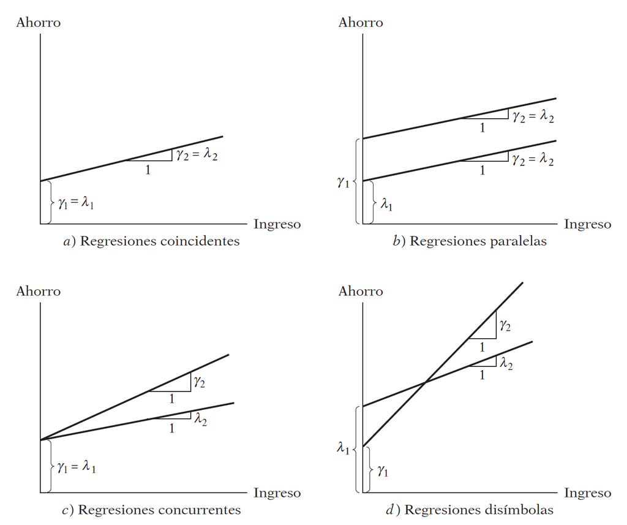

Para evaluar si hay diferencias, podemos utilizar los modelos de regresión con variables dicotómicas:

$$Y_t = \alpha_1+\alpha_2D_t+\beta_1X_t+\beta_2(D_tX_t)+u_t\label{chow3}$$

donde

- $Y$: ahorro
- $X$: ingreso
- $t$: tiempo
- $D$: 1 para el período 1982-1995, 0 en otro caso.

La variable dicotómica de la ecuacuión $\eqref{chow3}$ es quien me permite estimar las ecuaciones $\eqref{chow1}$ y $\eqref{chow2}$ al *mismo tiempo*. Es decir:

Función de ahorros medios para 1970-1981:

$$E(Y_t|D_t=0,X_t) = \alpha_1+\beta_1X_t$$

Función de ahorros medios para 1982-1995:

$$E(Y_t|D_t=1,X_t) = (\alpha_1+\alpha_2)+(\beta_1+\beta_2)X_t$$

Abrir los `datos 8.9`. Veamos las variables gráficamente:

```r
uu <- "https://raw.githubusercontent.com/vmoprojs/DataLectures/master/tabla_8_9.csv"

datos <- read.csv(url(uu),sep=";",dec=".",header=TRUE)
attach(datos)
names(datos)
```

```
## [1] "YEAR"    "SAVINGS" "INCOME"
```

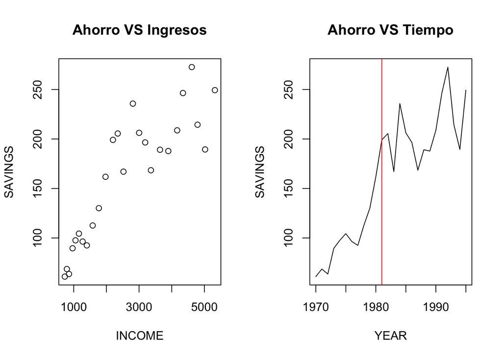

```r
par(mfrow = c(1,2))
plot(INCOME,SAVINGS,main="Ahorro VS Ingresos")
plot(YEAR,SAVINGS,main="Ahorro VS Tiempo",t="l")
abline(v=1981,col ="red")
```

```r
par(mfrow = c(1,1))
```

¿Hubo algún cambio en la relación entre ingreso y ahorro en el 80?

- Hay varias formas de hacer la prueba, la mas fácil es mediante variables dicotómicas

```r
ajuste_chow <- lm(SAVINGS~INCOME)
summary(ajuste_chow)
```

```
##
## Call:
## lm(formula = SAVINGS ~ INCOME)
##
## Residuals:
##     Min      1Q  Median      3Q     Max
## -62.236 -21.208  -9.271  18.726  67.399
##
## Coefficients:
##              Estimate Std. Error t value Pr(>|t|)
## (Intercept) 62.422671  12.760749   4.892 5.47e-05 ***
## INCOME       0.037679   0.004237   8.894 4.61e-09 ***
## ---
## Signif. codes:  0 '***' 0.001 '**' 0.01 '*' 0.05 '.' 0.1 ' ' 1
##
## Residual standard error: 31.12 on 24 degrees of freedom
## Multiple R-squared:  0.7672, Adjusted R-squared:  0.7575
## F-statistic:  79.1 on 1 and 24 DF,  p-value: 4.607e-09
```

```r
cambio <- (YEAR>1981)*1

ajuste_chow <- lm(SAVINGS~INCOME+cambio)
summary(ajuste_chow)
```

```
##
## Call:
## lm(formula = SAVINGS ~ INCOME + cambio)
##
## Residuals:
##     Min      1Q  Median      3Q     Max
## -53.053 -20.645  -4.828  15.793  69.159
##
## Coefficients:
##              Estimate Std. Error t value Pr(>|t|)
## (Intercept) 71.705871  13.545668   5.294 2.26e-05 ***
## INCOME       0.026468   0.007925   3.340  0.00285 **
## cambio      37.833470  22.905072   1.652  0.11217
## ---
## Signif. codes:  0 '***' 0.001 '**' 0.01 '*' 0.05 '.' 0.1 ' ' 1
##
## Residual standard error: 30.06 on 23 degrees of freedom
## Multiple R-squared:  0.7919, Adjusted R-squared:  0.7738
## F-statistic: 43.76 on 2 and 23 DF,  p-value: 1.446e-08
```

Veamos el modelo en términos de interacciones y la matriz de diseño:

```r
ajuste_chow1 <- lm(SAVINGS~INCOME+cambio+INCOME*cambio, x = TRUE)
summary(ajuste_chow1)
```

```
##
## Call:
## lm(formula = SAVINGS ~ INCOME + cambio + INCOME * cambio, x = TRUE)
##
## Residuals:
##     Min      1Q  Median      3Q     Max
## -38.729 -14.777  -1.398  11.689  50.535
##
## Coefficients:
##                Estimate Std. Error t value Pr(>|t|)
## (Intercept)     1.01612   20.16483   0.050 0.960266
## INCOME          0.08033    0.01450   5.541 1.44e-05 ***
## cambio        152.47855   33.08237   4.609 0.000136 ***
## INCOME:cambio  -0.06547    0.01598  -4.096 0.000477 ***
## ---
## Signif. codes:  0 '***' 0.001 '**' 0.01 '*' 0.05 '.' 0.1 ' ' 1
##
## Residual standard error: 23.15 on 22 degrees of freedom
## Multiple R-squared:  0.8819, Adjusted R-squared:  0.8658
## F-statistic: 54.78 on 3 and 22 DF,  p-value: 2.268e-10
```

```r
ajuste_chow1$x
```

```
##    (Intercept) INCOME cambio INCOME:cambio
## 1            1  727.1      0           0.0
## 2            1  790.2      0           0.0
## 3            1  855.3      0           0.0
## 4            1  965.0      0           0.0
## 5            1 1054.2      0           0.0
## 6            1 1159.2      0           0.0
## 7            1 1273.0      0           0.0
## 8            1 1401.4      0           0.0
## 9            1 1580.1      0           0.0
## 10           1 1769.5      0           0.0
## 11           1 1973.3      0           0.0
## 12           1 2200.2      0           0.0
## 13           1 2347.3      1        2347.3
## 14           1 2522.4      1        2522.4
## 15           1 2810.0      1        2810.0
## 16           1 3002.0      1        3002.0
## 17           1 3187.6      1        3187.6
## 18           1 3363.1      1        3363.1
## 19           1 3640.8      1        3640.8
## 20           1 3894.5      1        3894.5
## 21           1 4166.8      1        4166.8
## 22           1 4343.7      1        4343.7
## 23           1 4613.7      1        4613.7
## 24           1 4790.2      1        4790.2
## 25           1 5021.7      1        5021.7
## 26           1 5320.8      1        5320.8
## attr(,"assign")
## [1] 0 1 2 3
```

# Referencias

Gujarati, Damodar, and Dawn Porter. 2010. *Econometría*. 5th ed. México: McGRAW-HILL/INTERAMERICANA EDITORES, SS DE CV.